# Practica 06: Cointegración BMW y Volkswagen

Ignacio Ruiz de Zuazu Echevarría

6/12/2020

[link a GitHub](https://github.com/ignacio-ruiz-de-zuazu/Prediccion-practicas.git)

[figure not shown]

## Descripción y objetivos del trabajo

Siguiendo con la anterior práctica y utilizando los datos diarios de las dos series desde el año 2014, debemos analizar la cointegración que puede existir entre BMW y Volkswagen.

## Trading de Pares

Para este trabajo usaremos la librería Pair Trading o trading de Pares. El trading de pares consiste en localizar dos activos financieros que sigan la misma tendencia que en un momento se separa pero despues siguen la misma tendencia. Es muy util dentros de los hedge fund. Peligro: 2 series estan cointegradas pero nada te asegura de que vuelvan a estar en equilibrio Por ello, establecemos stock loss.

## Carga de datos

Para este trabajo emplearemos las series temporales sobre las cotizaciones de BMW y Volkswagen desde el 1 de enero de 2014 hasta el 25 de noviembre de 2020.

```r
bmw <- getSymbols("BMW.DE" ,from = "2014-01-01",to = "2020-11-25", auto.assign = FALSE)
volkswagen <- getSymbols("VOW.DE" ,from = "2014-01-01",to = "2020-11-25", auto.assign = FALSE)
xbmw = Ad(bmw)
xvolkswagen = Ad(volkswagen)
```

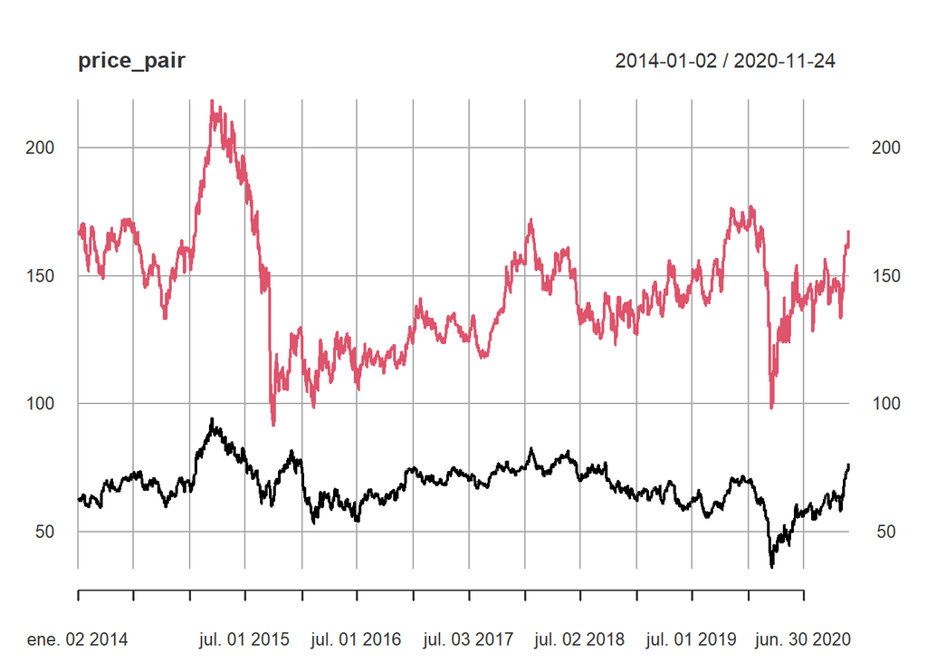

## Análisis de Cointegración

```
##
##  Augmented Dickey-Fuller Test
##
## data:  price_pair[, 1]
## Dickey-Fuller = -2.935, Lag order = 0, p-value = 0.1825
## alternative hypothesis: stationary
```

```
##
##  Augmented Dickey-Fuller Test
##
## data:  price_pair[, 2]
## Dickey-Fuller = -2.4611, Lag order = 0, p-value = 0.3831
## alternative hypothesis: stationary
```

Realizamos el test de Dickey-Fuller donde k = 0. La hipótesis nula es que la serie no es estacionaria. El p-valor en ambas series es superior a 0.05 y por lo tanto la serie es no estacionario y habría que aplicar una diferencia.

```
##
##  Augmented Dickey-Fuller Test
##
## data:  price_pair[, 1]
## Dickey-Fuller = -3.135, Lag order = 6, p-value = 0.09912
## alternative hypothesis: stationary
```

Se observa que siguen siendo no estacionarios. A continuación seleccionamos la k empleando el criterio AIC con un máximo de 10 retardos.

```
##
## ###############################################
## # Augmented Dickey-Fuller Test Unit Root Test #
## ###############################################
##
## Test regression none
##
##
## Call:
## lm(formula = z.diff ~ z.lag.1 - 1 + z.diff.lag)
##
## Residuals:
##     Min      1Q  Median      3Q     Max
## -5.9706 -0.5858 -0.0052  0.5794  5.4700
##
## Coefficients:
##               Estimate Std. Error t value Pr(>|t|)
## z.lag.1     -3.792e-05  3.881e-04  -0.098   0.9222
## z.diff.lag1  5.311e-02  2.406e-02   2.208   0.0274 *
## z.diff.lag2  2.267e-02  2.406e-02   0.942   0.3462
## z.diff.lag3  4.890e-02  2.406e-02   2.032   0.0423 *
## z.diff.lag4 -4.601e-02  2.405e-02  -1.913   0.0559 .
## ---
## Signif. codes:  0 '***' 0.001 '**' 0.01 '*' 0.05 '.' 0.1 ' ' 1
##
## Residual standard error: 1.106 on 1731 degrees of freedom
## Multiple R-squared:  0.007666,   Adjusted R-squared:  0.0048
## F-statistic: 2.675 on 5 and 1731 DF,  p-value: 0.02045
##
##
## Value of test-statistic is: -0.0977
##
## Critical values for test statistics:
##       1pct  5pct 10pct
## tau1 -2.58 -1.95 -1.62
```

A continuación aplicamos el mismo método, esta vez se selecciona mediante el criterio de tendencia.

```
##
## ###############################################
## # Augmented Dickey-Fuller Test Unit Root Test #
## ###############################################
##
## Test regression trend
##
##
## Call:
## lm(formula = z.diff ~ z.lag.1 + 1 + tt + z.diff.lag)
##
## Residuals:
##     Min      1Q  Median      3Q     Max
## -6.1237 -0.5961 -0.0067  0.5569  5.1639
##
## Coefficients:
##               Estimate Std. Error t value Pr(>|t|)
## (Intercept)  8.241e-01  2.644e-01   3.117  0.00186 **
## z.lag.1     -1.129e-02  3.544e-03  -3.187  0.00146 **
## tt          -5.735e-05  5.681e-05  -1.010  0.31281
## z.diff.lag1  5.801e-02  2.405e-02   2.413  0.01595 *
## z.diff.lag2  2.818e-02  2.406e-02   1.171  0.24182
## z.diff.lag3  5.467e-02  2.407e-02   2.271  0.02325 *
## z.diff.lag4 -3.966e-02  2.408e-02  -1.647  0.09973 .
## ---
## Signif. codes:  0 '***' 0.001 '**' 0.01 '*' 0.05 '.' 0.1 ' ' 1
##
## Residual standard error: 1.103 on 1729 degrees of freedom
## Multiple R-squared:  0.01347,    Adjusted R-squared:  0.01005
## F-statistic: 3.935 on 6 and 1729 DF,  p-value: 0.0006521
##
##
## Value of test-statistic is: -3.1873 3.419 5.0948
##
## Critical values for test statistics:
##       1pct  5pct 10pct
## tau3 -3.96 -3.41 -3.12
## phi2  6.09  4.68  4.03
## phi3  8.27  6.25  5.34
```

Value of test-statistic is: -3.1873 3.419 5.0948

Solo hay que fijarse en el tau3 para la estacionaridad.

Ahora se estiman los parametros de la relación de equilibrio entre la serie de BMW y la serie de Volkswagen.

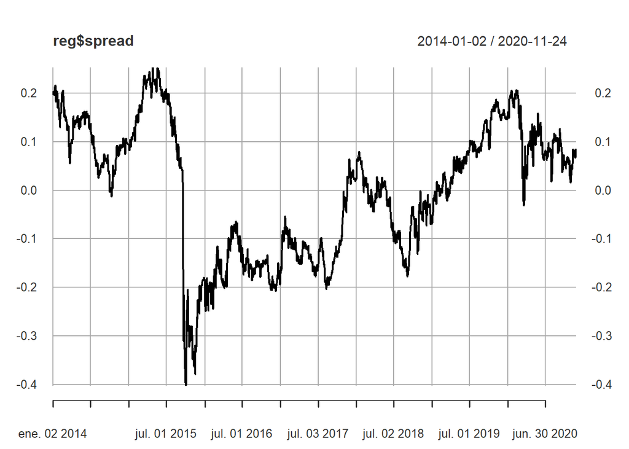

Observando la gráfica, cuanto más abajo, existirá una mayor separación entre las series y por el contrario. Si la tendencia sigue hacia abajo podemos tener pérdidas. El spread es el error del modelo de equilibrio en la relacion a largo plazo. La cobertura en este caso sería de 0.586.

```
##  PP.test adf.test
##    FALSE    FALSE
```

Realizamos un otra vez el test de Dickey-Fuller nos dice que las dos series no son estacionarias por lo tanto hay que tener cuidado.

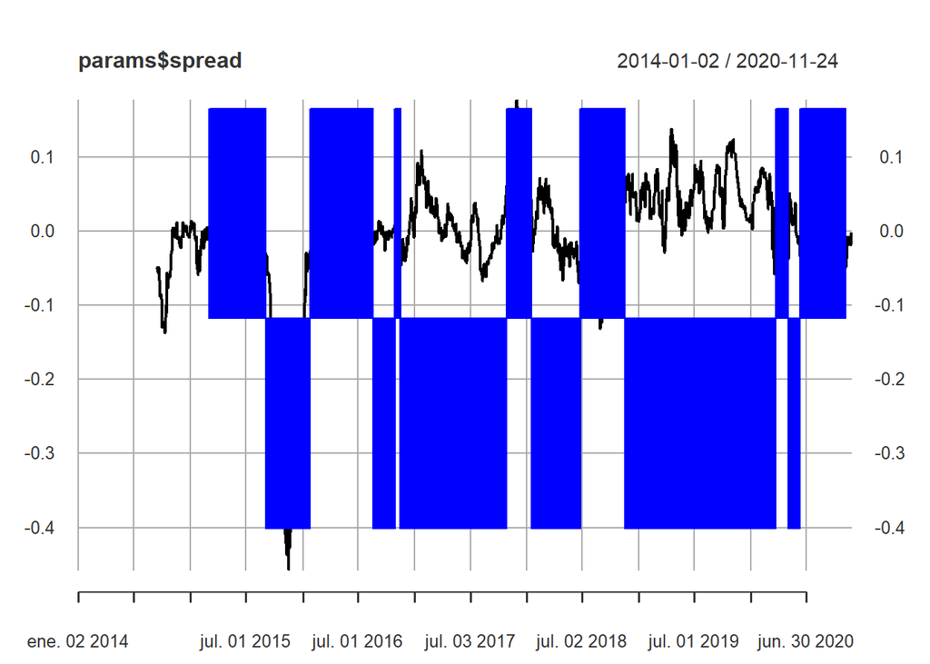

En esta gráfica se observa la señal, que se ha calculado a partir de los parámetros del spread cogiendo 180 observaciones. La señal nos indica cuando se debe de entrar y salir en función del spread. La parte de arriba significa que estamos dentro en la estrategia y abajo fuera en la estrategia. En esta gráfica se supone que siempre nos encontramos dentro del mercado. En la parte superior nos encontrariamos comprando acciones de BMW mientras que vendemos acciones de Volkswagen.

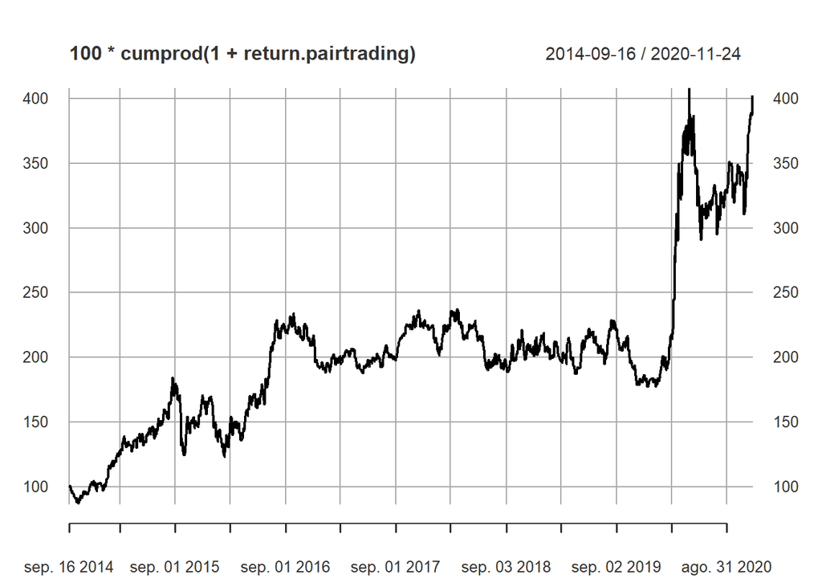

Esta gráfica nos muestra el beneficio de la estrategia anteriormente planteada durante todo este periodo.